# Introduction to bayesplot (mcmc_ series)

こちらは、Stan advent ([Link](https://qiita.com/advent-calendar/2018/stan)) 2日目の記事になります。  
お前誰や？？→→[HPに行く](https://dastatis.github.io/index.html)

昨日の小杉先生M1の記事は面白かったですね!!!  
今日は、baysplotの紹介をしたいと思います。

# bayesplot packageについて

Stan楽しいですね(*´Д`)ﾊｧﾊｧ

ベイズ推定をするのも楽しいですが、ただベイズ推定して終わりではなく、結果の解釈が一番大事であり、その前にやるべきこともあります。

Stanでパラメータ推定を行う場合MCMC(HMC)を行うと思いますが、**推定がきちんと終わっているか(収束しているか)**を確認することは非常に大事です。

- 推定の確認方法として以下をみることが一般的かと思います。
  - パラメータ推定が収束しているかを確認する(Gelman-Rubin診断の$\hat{R}$等)
  - パラメータ推定(MCMC)が安定しているか確認する(effective sample size(n_eff/ESS)やauto correlation等※)
  - 事後分布を確認
  - 事後予測チェックをする

※ ESSの計算にauto correlationを使っているので、別物ではありませんが…  
(そういや最近、Stanのauto correlationの近似方法が変わりましたね。。。)

Stanには、既にggplot2ライクな事後処理用の関数が標準装備されています。  
ここら辺に関しては、以下の資料をご覧ください。

Stan便利な事後処理関数[SlideShare](https://www.slideshare.net/daikihojo/stan-70425025)

これとは別にStan公式が出しているbayesplotパッケージというものがあって、これも同じようなことができます。  
既に日本語文献として小杉先生のサイトで紹介されていました([こちら](http://kosugitti.net/archives/6078))。  
上記も併せてご覧ください。この記事を書くうえでも参考にしています。

bayesplotパッケージでは、大きく二つの関数系に分かれています  
1. mcmc_ シリーズ(収束や事後分布を確認するための関数群)  
2. ppc_ シリーズ(事後予測チェックを行うのに便利な関数群)

この記事では、1.のmcmc_シリーズの説明を行います。  
2.については誰かもしくは未来の自分がやってくれることでしょうｗ

# 使う前の準備

とりあえず適当にStanを回します。  
今回は、デモで最もよく使われるであろう8schoolモデルを回します。  
今回は特に事後処理の説明のみするので、ここではモデルがどうなっているかを見る必要はありません。

```r
# setwd('')

rm(list = ls())
library(tidyverse)  ## ほぼパイプのために読み込んでいます。
library(rstan)
library(bayesplot)  ## こいつが今回の主役です。
rstan_options(auto_write = TRUE)  ## なくても構いません
options(mc.cores = parallel::detectCores())  ## なくても構いません
options(max.print = 99999)  ## なくても構いません
```

そして、使うデータを準備します。

```r
schools_dat <- list(J = 8, y = c(28, 8, -3, 7, -1, 1, 18, 12), sigma = c(15,
    10, 16, 11, 9, 11, 10, 18))
```

# Stan model

今回回すStanモデルはこちらです。

```stan
data {
  int<lower=0> J;
  real y[J];
  real<lower=0> sigma[J];
}

parameters {
  real mu;
  real<lower=0> tau;
  real eta[J];
}

transformed parameters {
  real theta[J];
  for (j in 1:J)
    theta[j] = mu + tau * eta[j];
}

model {
  target += normal_lpdf(eta | 0, 1);
  target += normal_lpdf(y | theta, sigma);
}
```

上記を自分で動かすなら、model.stanと保存して、R上で以下を実行してください。  
[モデルをダウンロードする](https://raw.githubusercontent.com/dastatis/dastatis.github.io/master/pdf/StanAdvent2018/model.stan)

```r
model <- stan_model("model.stan")
```

# Stanを回す

以下でStanが回ります。

```r
fit <- sampling(object = model, data = schools_dat, iter = 1000, chains = 4)

## 結果 ##
fit
```

```
Inference for Stan model: 4a38cae9bad394789360bce03f17c3ed.
4 chains, each with iter=1000; warmup=500; thin=1;
post-warmup draws per chain=500, total post-warmup draws=2000.

           mean se_mean   sd   2.5%    25%    50%    75%  97.5% n_eff Rhat
mu         8.05    0.14 4.96  -1.50   4.82   8.14  11.14  18.17  1243 1.00
tau        6.25    0.16 5.19   0.25   2.32   5.17   8.85  19.03  1042 1.00
eta[1]     0.40    0.02 0.94  -1.54  -0.21   0.40   1.05   2.18  1824 1.00
eta[2]     0.00    0.02 0.94  -1.86  -0.62  -0.01   0.62   1.90  1555 1.00
eta[3]    -0.20    0.02 0.97  -2.14  -0.84  -0.19   0.43   1.74  1794 1.00
eta[4]    -0.06    0.02 0.87  -1.82  -0.61  -0.05   0.49   1.65  1968 1.00
eta[5]    -0.36    0.02 0.90  -2.14  -0.95  -0.40   0.21   1.50  1719 1.00
eta[6]    -0.23    0.02 0.91  -1.98  -0.83  -0.26   0.36   1.65  1983 1.00
eta[7]     0.32    0.02 0.86  -1.45  -0.24   0.36   0.89   1.97  1958 1.00
eta[8]     0.07    0.02 0.94  -1.78  -0.58   0.09   0.70   1.94  1839 1.00
theta[1]  11.54    0.21 8.35  -1.63   6.19  10.36  15.45  31.23  1550 1.00
theta[2]   7.93    0.14 6.47  -5.21   3.95   7.76  11.95  20.60  2051 1.00
theta[3]   6.25    0.18 7.90 -12.11   2.25   6.67  11.21  20.69  1830 1.00
theta[4]   7.60    0.14 6.36  -6.39   3.84   7.86  11.52  19.67  2058 1.00
theta[5]   5.38    0.14 6.43  -8.40   1.73   5.78   9.52  16.85  2041 1.00
theta[6]   6.23    0.15 6.63  -8.51   2.50   6.66  10.51  18.56  1995 1.00
theta[7]  10.67    0.15 6.70  -0.99   6.28  10.21  14.35  26.00  2031 1.00
theta[8]   8.85    0.18 7.69  -5.32   4.19   8.50  13.01  24.97  1833 1.00
lp__     -39.73    0.10 2.65 -45.60 -41.39 -39.43 -37.81 -35.34   728 1.01

Samples were drawn using NUTS(diag_e) at Sat Dec 01 12:41:12 2018.
For each parameter, n_eff is a crude measure of effective sample size,
and Rhat is the potential scale reduction factor on split chains (at
convergence, Rhat=1).
```

# bayesplotを使う [本番]

## $\hat{R}$の確認

一般的に$\hat{R}<1.10$で収束とみなすと思います。

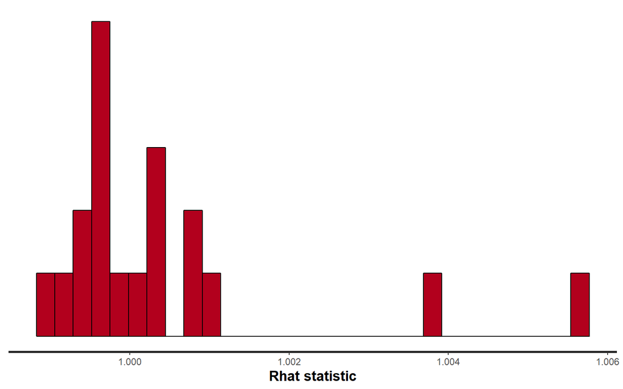

```r
## デフォルト not bayesplot
stan_rhat(fit)
```

```r
stan_rhat(fit)$data  ## dataとしてとってきたい
```

```
              stat
mu       0.9992001
tau      1.0038763
eta[1]   1.0004295
eta[2]   0.9995890
eta[3]   1.0003983
eta[4]   0.9994688
eta[5]   1.0001802
eta[6]   0.9996924
eta[7]   1.0003880
eta[8]   0.9997078
theta[1] 0.9995893
theta[2] 0.9989432
theta[3] 1.0008485
theta[4] 0.9996523
theta[5] 1.0009598
theta[6] 0.9997703
theta[7] 0.9994518
theta[8] 1.0007286
lp__     1.0056553
```

```r
## bayesplot

## rhatがdataとして出力される
rhat(fit)
```

```
       mu       tau    eta[1]    eta[2]    eta[3]    eta[4]    eta[5]
0.9992001 1.0038763 1.0004295 0.9995890 1.0003983 0.9994688 1.0001802
   eta[6]    eta[7]    eta[8]  theta[1]  theta[2]  theta[3]  theta[4]
0.9996924 1.0003880 0.9997078 0.9995893 0.9989432 1.0008485 0.9996523
 theta[5]  theta[6]  theta[7]  theta[8]      lp__
1.0009598 0.9997703 0.9994518 1.0007286 1.0056553
```

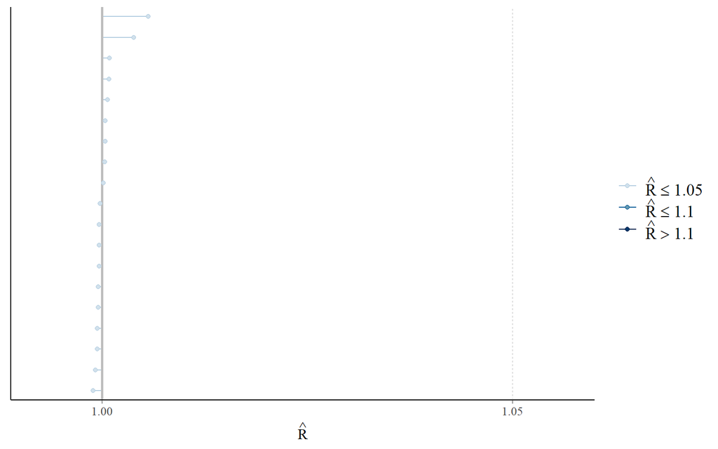

```r
## rhatが図として出力
mcmc_rhat(rhat(fit))
```

```r
## 表示した図に関するdata
mcmc_rhat_data(rhat(fit))
```

```
# A tibble: 19 x 5
   diagnostic parameter value rating description
   <chr>      <fct>     <dbl> <fct>  <chr>
 1 rhat       theta[2]  0.999 low    hat(R) > 1.1
 2 rhat       mu        0.999 low    hat(R) > 1.1
 3 rhat       theta[7]  0.999 low    hat(R) > 1.1
 4 rhat       eta[4]    0.999 low    hat(R) > 1.1
 5 rhat       eta[2]    1.000 low    hat(R) > 1.1
 6 rhat       theta[1]  1.000 low    hat(R) > 1.1
 7 rhat       theta[4]  1.000 low    hat(R) > 1.1
 8 rhat       eta[6]    1.000 low    hat(R) > 1.1
 9 rhat       eta[8]    1.000 low    hat(R) > 1.1
10 rhat       theta[6]  1.000 low    hat(R) > 1.1
11 rhat       eta[5]    1.00  low    hat(R) > 1.1
12 rhat       eta[7]    1.00  low    hat(R) > 1.1
13 rhat       eta[3]    1.00  low    hat(R) > 1.1
14 rhat       eta[1]    1.00  low    hat(R) > 1.1
15 rhat       theta[8]  1.00  low    hat(R) > 1.1
16 rhat       theta[3]  1.00  low    hat(R) > 1.1
17 rhat       theta[5]  1.00  low    hat(R) > 1.1
18 rhat       tau       1.00  low    hat(R) > 1.1
19 rhat       lp__      1.01  low    hat(R) > 1.1
```

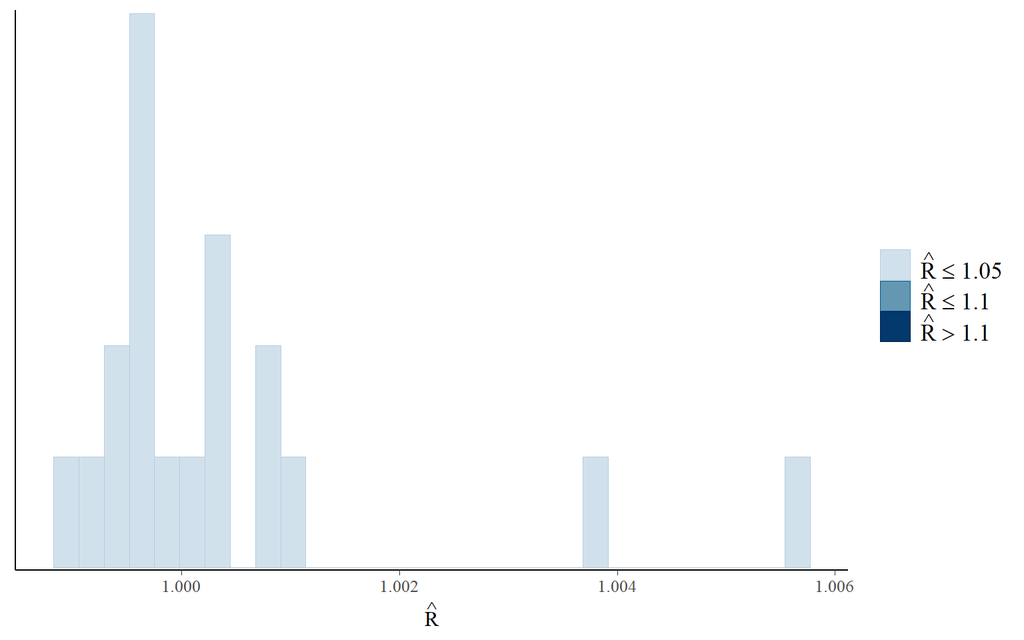

```r
## histgramとして表示(stan_rhatに近い形で出力)
mcmc_rhat_hist(rhat(fit))
```

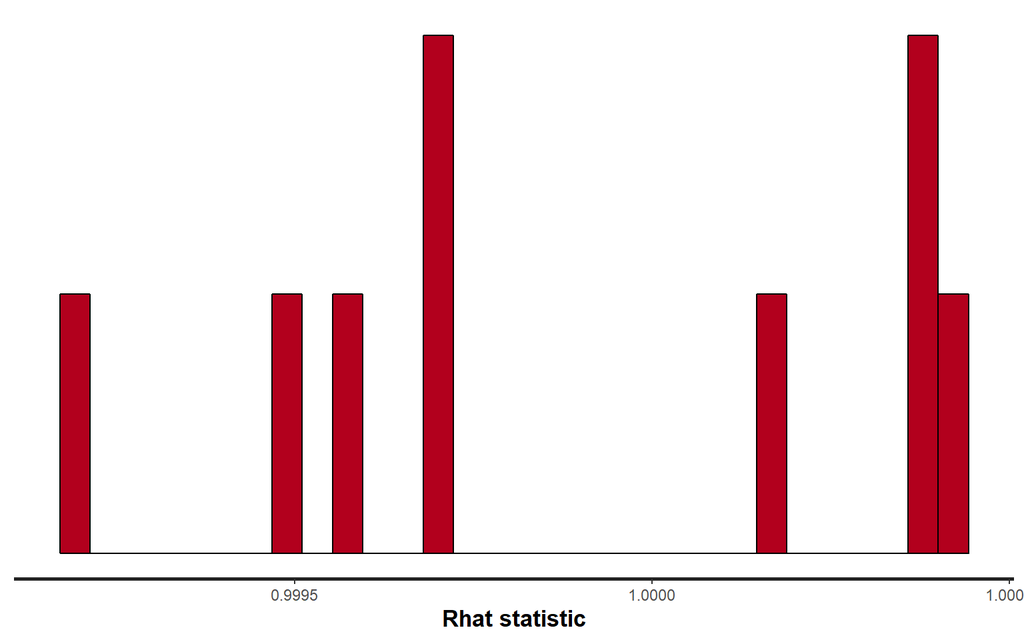

```r
## 特定のパラメータのR hat をみたい。
stan_rhat(fit, pars = c("mu", "eta"))  ## stanの関数
```

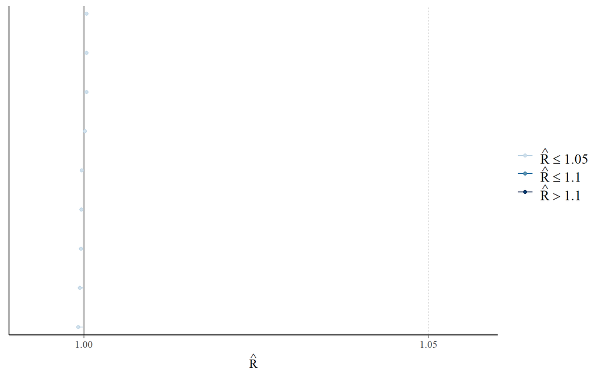

```r
mcmc_rhat(rhat(fit, pars = c("mu", "eta")))  ## bayesplotの関数
```

使う上でのポイントは,パラメータを指定するしないにかかわらず,**rhat()関数にいれてから、mcmc_rhat()にいれて出力**  
stan_rhat()でええやん

## traceplotを見る

bayesplotを使うためには、stanの結果ファイルを配列(array)型にする必要があります。  
stanオブジェクトを配列型にすると、[iter,chains,pars]の3次元配列になります。

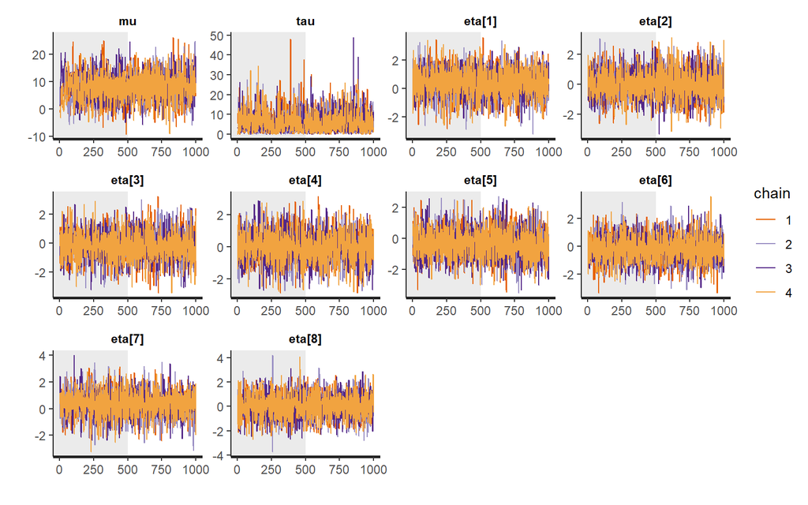

```r
## デフォルト
stan_trace(fit, inc_warmup = T)  ## inc_warmupでwarmup区間指定可能
```

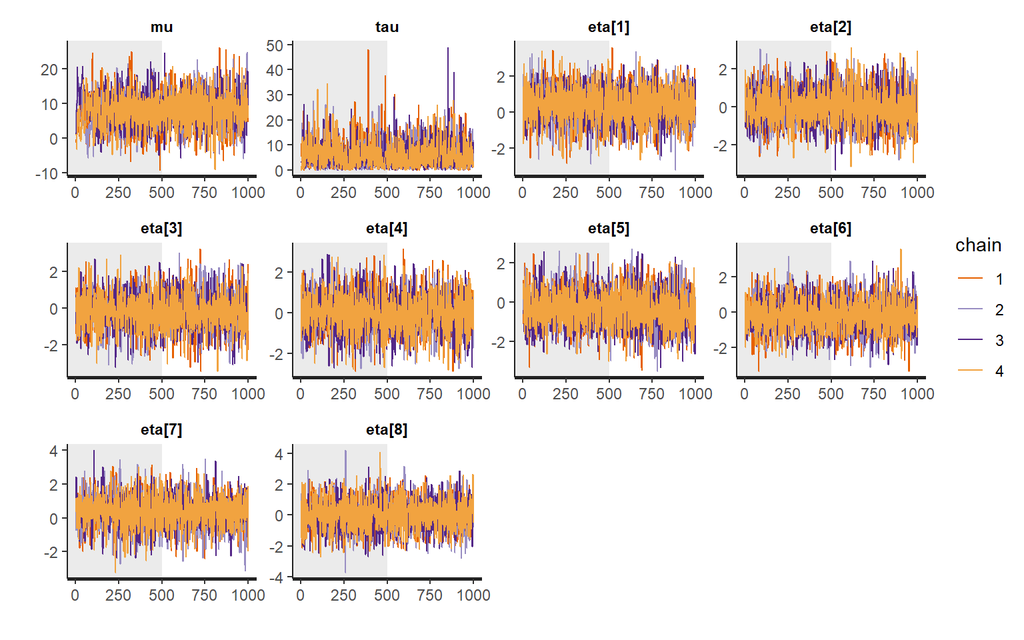

```r
traceplot(fit, inc_warmup = T)
```

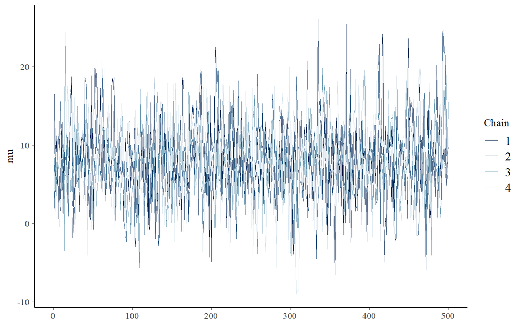

```r
## bayesplot
samples <- as.array(fit)
mcmc_trace(samples, pars = "mu")  ## n_warmupでwarmup区間指定可能
```

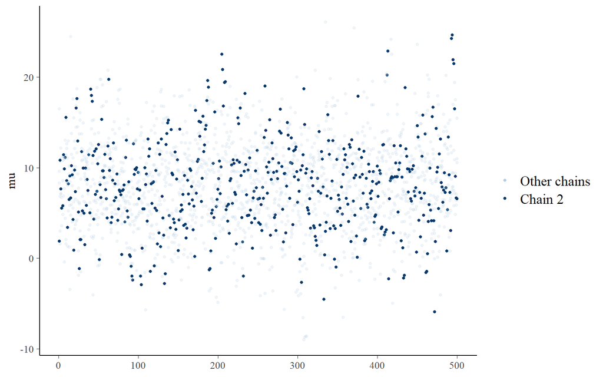

```r
## 特定のchainを特に見たい(目立たせて確認したい)
mcmc_trace_highlight(samples, pars = "mu", highlight = 2)
```

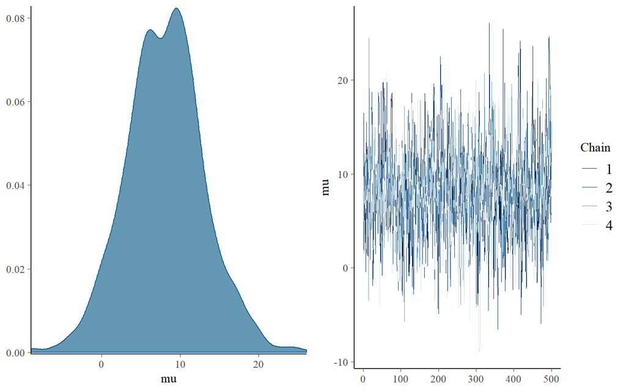

```r
## 事後分布と同時に確認したい(パラメータ多いと重いので指定推奨)
mcmc_combo(samples, pars = c("mu"))
```

ポイントは、stanオブジェクトを配列型に変換してからわたすこと。  
また、n_warmupの挙動が若干謎。おそらく、warmupとそのあとを同時にプロットできなそう？

stan_trace()でええやん

## auto correlation(自己相関)を確認

自己相関を見るためにも、配列型にする必要があります。先ほどのas.array(fit)をやるのを忘れずに。

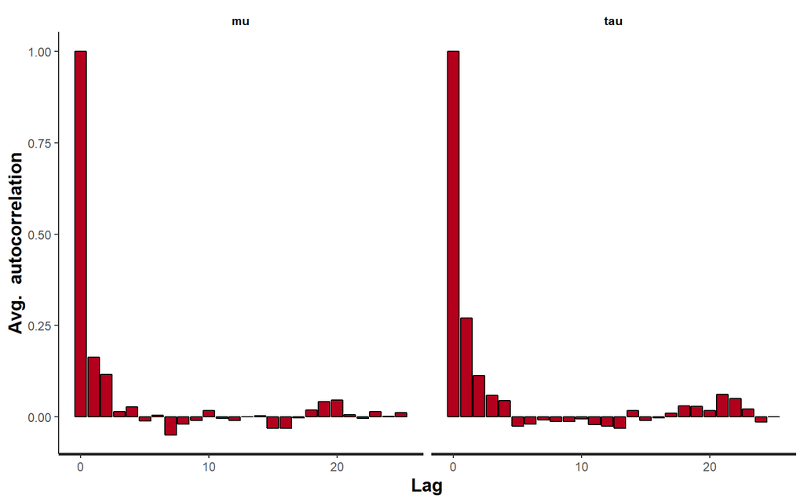

```r
## デフォルト
stan_ac(fit, pars = c("mu", "tau"))
```

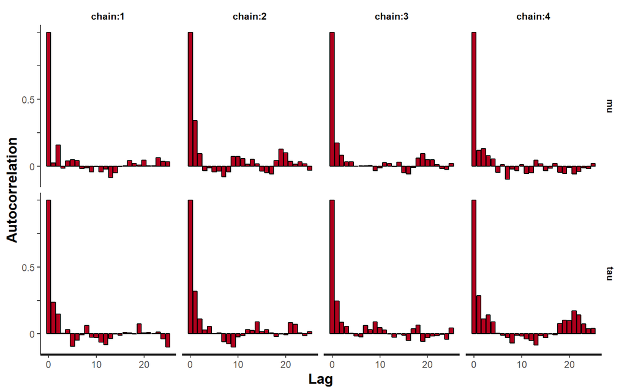

```r
## chain別
stan_ac(fit, pars = c("mu", "tau"), separate_chains = T)
```

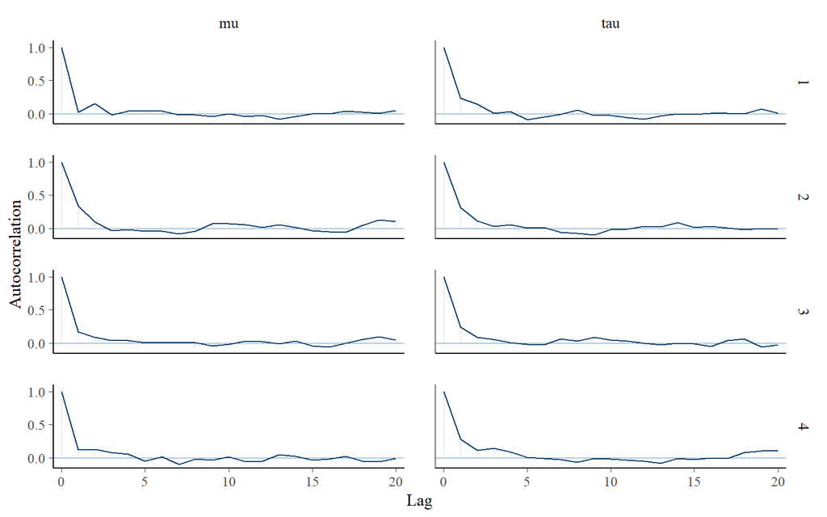

```r
## bayesplot

## 折れ線表記
mcmc_acf(samples, pars = c("mu", "tau"))
```

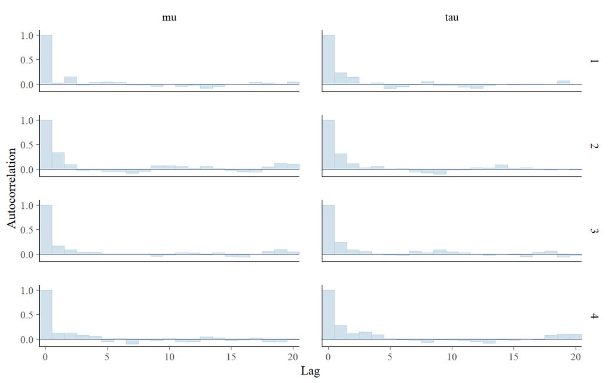

```r
## 棒グラフ表記
mcmc_acf_bar(samples, pars = c("mu", "tau"))
```

stan_ac()でええやん

## ESS(n_eff)を確認

続いて、実行(有効)サンプルサイズを確認したいと思います。  
今回は、stanオブジェクトをそのまま使うことができます。  
一般的にこの値が10％(0.1)以下になると自己相関が高くMCMCが**うまくいっていない**と判断されます。

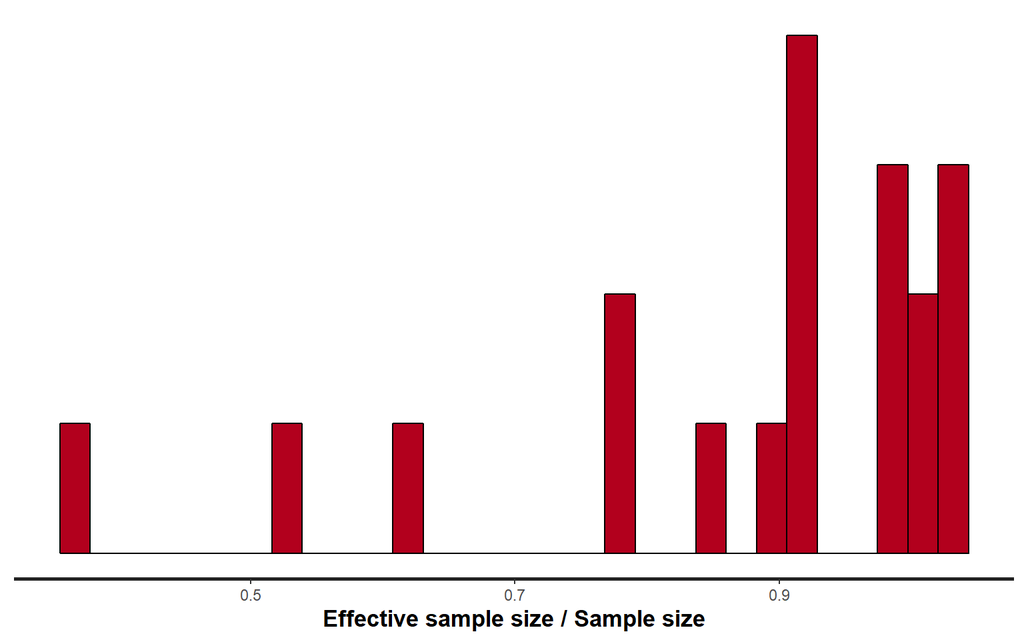

```r
## デフォルト
stan_ess(fit)
```

```r
stan_ess(fit)$data  ## dataとして出力
```

```
              stat
mu       0.6212756
tau      0.5211331
eta[1]   0.9120741
eta[2]   0.7774456
eta[3]   0.8970617
eta[4]   0.9837958
eta[5]   0.8594550
eta[6]   0.9912680
eta[7]   0.9790504
eta[8]   0.9192841
theta[1] 0.7748646
theta[2] 1.0252659
theta[3] 0.9149762
theta[4] 1.0290931
theta[5] 1.0205462
theta[6] 0.9975286
theta[7] 1.0152921
theta[8] 0.9165216
lp__     0.3641157
```

```r
## bayesplot

## n_effの値をdataとして確認
neff_ratio(fit)
```

```
       mu       tau    eta[1]    eta[2]    eta[3]    eta[4]    eta[5]
0.6212756 0.5211331 0.9120741 0.7774456 0.8970617 0.9837958 0.8594550
   eta[6]    eta[7]    eta[8]  theta[1]  theta[2]  theta[3]  theta[4]
0.9912680 0.9790504 0.9192841 0.7748646 1.0252659 0.9149762 1.0290931
 theta[5]  theta[6]  theta[7]  theta[8]      lp__
1.0205462 0.9975286 1.0152921 0.9165216 0.3641157
```

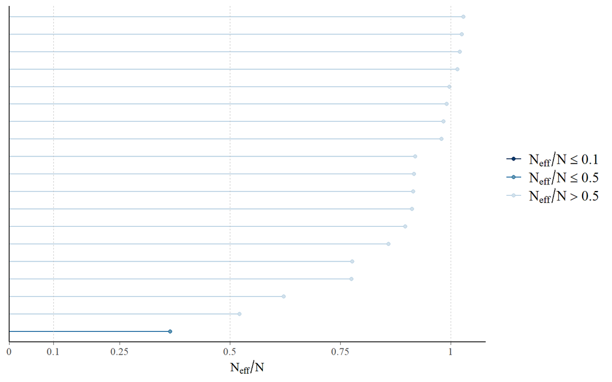

```r
## 図で確認
mcmc_neff(neff_ratio(fit))
```

```r
mcmc_neff_data(neff_ratio(fit))  ## 図で出力したdataを出力
```

```
# A tibble: 19 x 5
   diagnostic parameter value rating description
   <chr>      <fct>     <dbl> <fct>  <chr>
 1 neff_ratio lp__      0.364 ok     N[eff]/N <= 0.5
 2 neff_ratio tau       0.521 high   N[eff]/N <= 0.1
 3 neff_ratio mu        0.621 high   N[eff]/N <= 0.1
 4 neff_ratio theta[1]  0.775 high   N[eff]/N <= 0.1
 5 neff_ratio eta[2]    0.777 high   N[eff]/N <= 0.1
 6 neff_ratio eta[5]    0.859 high   N[eff]/N <= 0.1
 7 neff_ratio eta[3]    0.897 high   N[eff]/N <= 0.1
 8 neff_ratio eta[1]    0.912 high   N[eff]/N <= 0.1
 9 neff_ratio theta[3]  0.915 high   N[eff]/N <= 0.1
10 neff_ratio theta[8]  0.917 high   N[eff]/N <= 0.1
11 neff_ratio eta[8]    0.919 high   N[eff]/N <= 0.1
12 neff_ratio eta[7]    0.979 high   N[eff]/N <= 0.1
13 neff_ratio eta[4]    0.984 high   N[eff]/N <= 0.1
14 neff_ratio eta[6]    0.991 high   N[eff]/N <= 0.1
15 neff_ratio theta[6]  0.998 high   N[eff]/N <= 0.1
16 neff_ratio theta[7]  1.02  high   N[eff]/N <= 0.1
17 neff_ratio theta[5]  1.02  high   N[eff]/N <= 0.1
18 neff_ratio theta[2]  1.03  high   N[eff]/N <= 0.1
19 neff_ratio theta[4]  1.03  high   N[eff]/N <= 0.1
```

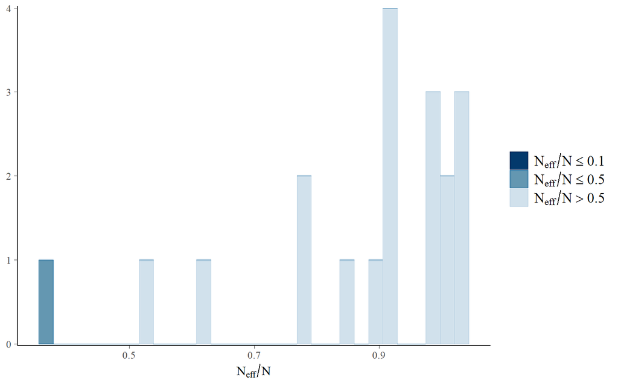

```r
mcmc_neff_hist(neff_ratio(fit))  ## stan_ess()形式で出力
```

ポイントは、neff_ratio()を通してから、出力させること。  
stan_ess()でええやん

## 事後分布を確認する

ここからは、事後分布を様々な視点から確認していきたいと思います。

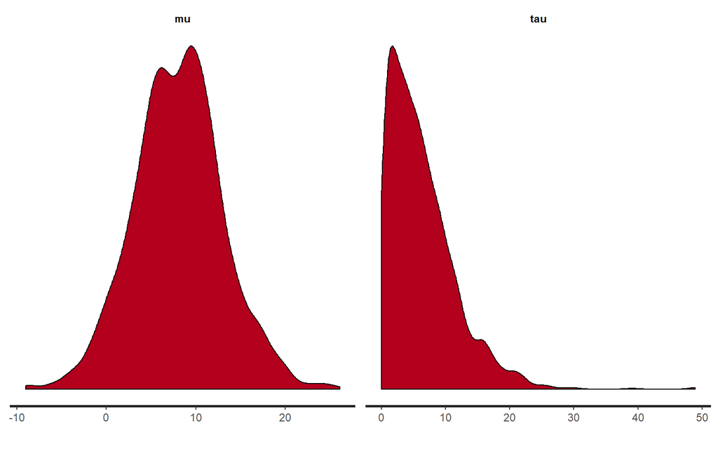

```r
## デフォルト
stan_dens(fit, pars = c("mu", "tau"))
```

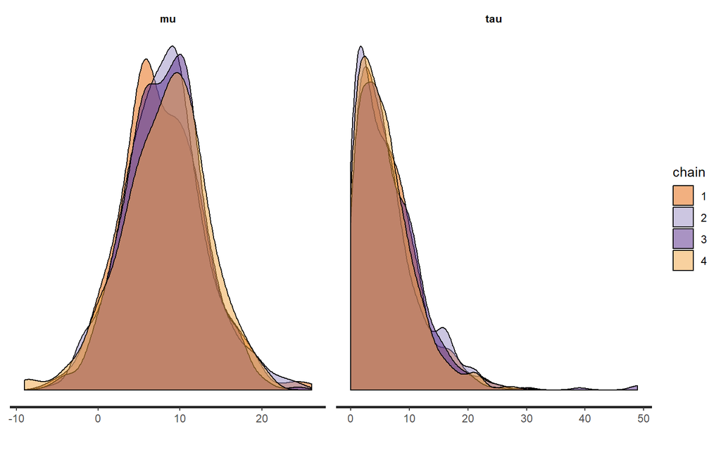

```r
stan_dens(fit, pars = c("mu", "tau"), separate_chains = T)
```

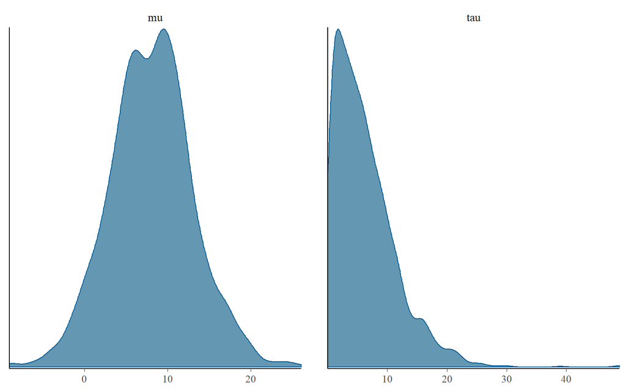

```r
# stan_dens(fit,pars=c('mu','tau'))$data

## beyasplot
mcmc_dens(samples, pars = c("mu", "tau"))
```

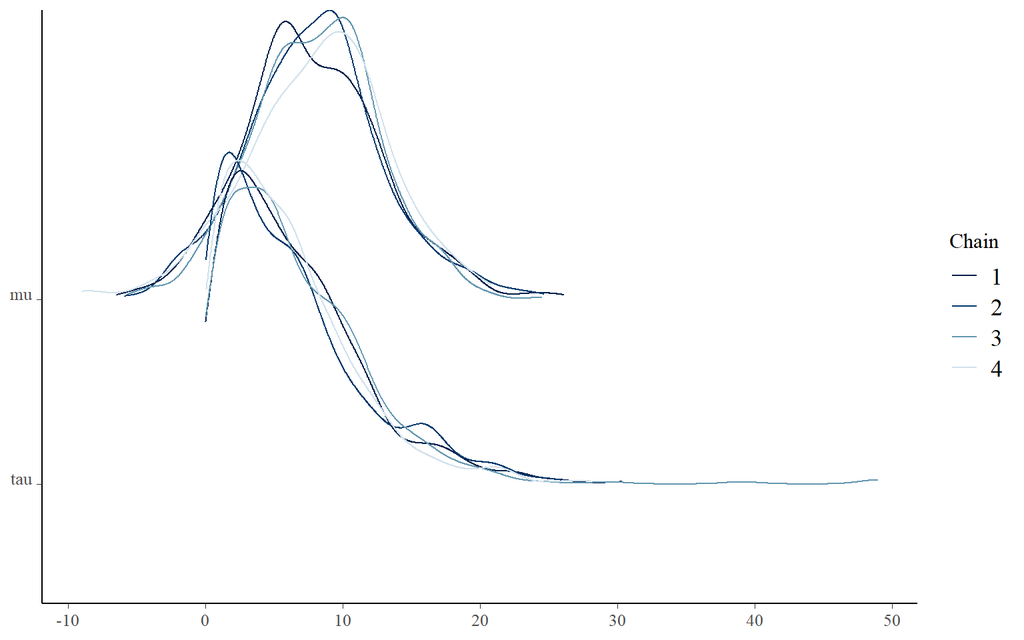

```r
## chainごとに出力(ただ、一度に出す)
mcmc_dens_chains(samples, pars = c("mu", "tau"))
```

```r
mcmc_dens_chains_data(samples, pars = c("mu", "tau"))  ## 上図のdataを取ってきたい場合
```

```
# A tibble: 8,192 x 6
   chain parameter interval_width     x density scaled_density
   <fct> <fct>              <dbl> <dbl>   <dbl>          <dbl>
 1 1     mu                     1 -6.52 0.00146         0.0174
 2 1     mu                     1 -6.49 0.00149         0.0178
 3 1     mu                     1 -6.46 0.00152         0.0182
 4 1     mu                     1 -6.42 0.00155         0.0185
 5 1     mu                     1 -6.39 0.00159         0.0189
 6 1     mu                     1 -6.36 0.00162         0.0193
 7 1     mu                     1 -6.33 0.00165         0.0197
 8 1     mu                     1 -6.30 0.00168         0.0201
 9 1     mu                     1 -6.27 0.00172         0.0205
10 1     mu                     1 -6.23 0.00175         0.0209
# ... with 8,182 more rows
```